# Reproducible Research: Peer Assessment 1

# Reproducible Research - Course Project 1

This project satifies the requirements set forth in the John Hopkins University’s Reproducilbe Research Course Project 1. The data for this assigment was retrieved from the course web site:

```
Dataset: [Activity monitoring data](https://d396qusza40orc.cloudfront.net/repdata%2Fdata%2Factivity.zip)
```

The data set above was downloaded and extracted with the following code:

```r
# clean the global environment
rm(list = ls())
# set the working directory to the Course-Project-1 director
setwd("~/Documents/Coursera/Reproducable-Research/Course-Project-1")

# check to see if the file has been downloaded, if not, download the file
if (!file.exists("./Data/repdata%2Fdata%2Factivity.zip")) {
  download.file("https://d396qusza40orc.cloudfront.net/repdata%2Fdata%2Factivity.zip", "./Data/repdata%2Fdata%2Factivity.zip", method = "curl")

}

# check to see if the archives.csv exists, if not, extract it
if (!file.exists("./Data/archives.csv")) {
  unzip("./Data/repdata%2Fdata%2Factivity.zip", exdir = "./Data/")

}

# read the csv and load the activity object
# format the date column as a date value
activity <- read.csv("./Data/activity.csv", stringsAsFactors = FALSE)
activity$date <- as.Date(activity$date)
```

The activity variables included loaded from the ataset are:

- steps: Number of steps taking in a 5-minute interval (missing values are coded as NA)
- date: The date on which the measurement was taken in YYYY-MM-DD format
- interval: Identifier for the 5-minute interval in which measurement was taken

17,568 observations were loaded from the dataset into the activity object.

## What is mean total number of steps taken per day?

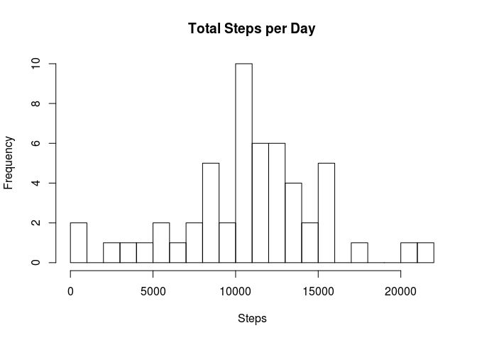

```r
echo = TRUE
# Question 1: What is mean total number of steps taken per day?
q1 <- aggregate(steps ~ date, data=activity, sum, na.rm = TRUE)
hist(q1$steps, breaks=20, main="Total Steps per Day", xlab="Steps")
```

```r
# Calculate the mead and median
s <- summary(q1$steps)
Mean_number_of_steps <- paste("The mean number of steps is: ", s["Mean"])
print(Mean_number_of_steps)
```

```
## [1] "The mean number of steps is:  10770"
```

```r
Median_number_of_steps <- paste("The median number of steps is: ", s["Median"])
print(Median_number_of_steps)
```

```
## [1] "The median number of steps is:  10760"
```

## What is the average daily activity pattern?

A time series plot was made using type = “l” by plotting the 5-minute interval and the average number of steps across all days.

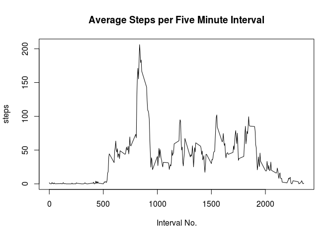

```r
echo=TRUE
# Question 2: What is the average daily activity pattern?
stepsdata <- aggregate(steps ~ interval, data=activity, mean, na.rm=TRUE)
plot(stepsdata$interval, stepsdata$steps, type="l", main="Average Steps per Five Minute Interval",
     xlab="Interval No.", ylab="steps")
```

```r
maxsteps <- max(stepsdata$steps)
print(paste("The maximum number of steps in a five minute interval was: ", maxsteps))
```

```
## [1] "The maximum number of steps in a five minute interval was:  206.169811320755"
```

```r
# Missing values in steps
# Approach is to fill NAs with the median value

# Report the number of missing values
missingdata <- sum(is.na(activity$steps))
print(paste("There are", missingdata, "missing data points."))
```

```
## [1] "There are 2304 missing data points."
```

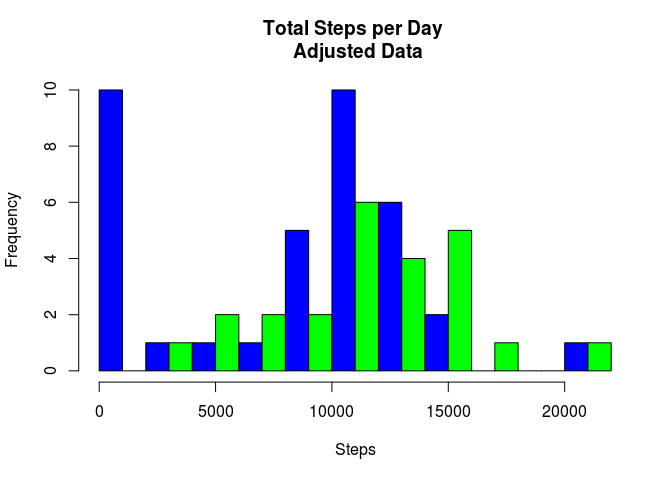

```r
# Adjusted NA values
Adjdata <- activity
Adjdata$steps[is.na(Adjdata$steps)] <- median(activity$steps, na.rm=TRUE)
Adjdataday <- aggregate(steps ~ date, data=Adjdata, sum, na.rm=TRUE)
hist(Adjdataday$steps, breaks=20, main="Total Steps per Day \n Adjusted Data",
     xlab="Steps", ylab="Frequency", col = c("blue", "green"))
```

```r
bsteps_mean <- mean(Adjdata$steps)
bsteps_median <- median(Adjdata$steps)
print(paste("The mean is: ", bsteps_mean))
```

```
## [1] "The mean is:  32.4799635701275"
```

```r
print(paste("The median is: ", bsteps_median))
```

```
## [1] "The median is:  0"
```

## Are there differences in activity patterns between weekdays and weekends?

Two 2 plots were created to answer this question. The use of the R weekdays function added the day of the week based on the date. An additional column was added that categorized the date as either weekday or weekend. A plot for the weekend and weekday(s) was created. By visually comparing the 2 plots, sustained weekend activity was stronger.

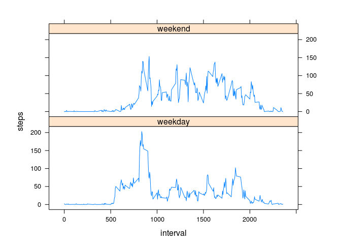

```r
# Weekend vs Weekday activity
# already performed betterdata$date <- as.Date(betterdata$date)
Adjdata$dayname <- weekdays(Adjdata$date)
Adjdata$weekend <- as.factor(ifelse(Adjdata$dayname == "Saturday" |
                                         Adjdata$dayname == "Sunday", "weekend", "weekday"))
library(lattice)
plotdata <- aggregate(steps ~ interval + weekend, Adjdata, mean)
xyplot(steps ~ interval | factor(weekend), data=plotdata, aspect=1/3, type="l")
```

Visual inspection of the 2 graphs indicates that the area under the curve of the weekend graph is higher.